# NRN_post

Richard Kunert (RiKunert@gmail.com)

4 Januar 2017

This blog post was published on [Brain’s Idea](https://brainsidea.wordpress.com/).

# How to write a nature-style review

Nature Reviews Neuroscience is one of the foremost journals in neuroscience. What do its articles look like? How have they developed? This blog posts provides answers which might guide you in writing your own reviews.

## Preparation

Before we start, we need to run some preparatory code.

```r
###################################################################################################
# load libraries

if(!require(devtools)){install.packages('devtools')} #RPP functions
library(devtools)
source_url('https://raw.githubusercontent.com/FredHasselman/toolboxR/master/C-3PR.R')

if(!require(Hmisc)){install.packages('Hmisc')}# correlations
library(Hmisc)

if(!require(MASS)){install.packages('MASS')}# robust correlations
library(MASS)

if(!require(psychometric)){install.packages('psychometric')}# robust correlations
library(psychometric)

###################################################################################################
# load data

load(url("https://github.com/rikunert/NRNweb/raw/master/NRNdat_2016-12-23.RData"))

###################################################################################################
# visualise data

########################################################
#prepare general look (very clean)

theme_set(theme_bw(18)+#remove gray background, set font-size
            theme(axis.line = element_line(colour = "black"),
                  panel.grid.major = element_blank(),
                  panel.grid.minor = element_blank(),
                  panel.background = element_blank(),
                  panel.border = element_blank(),
                  legend.key = element_blank(),
                  legend.title = element_blank(),#remove all sorts of lines for a cleaner look
                  legend.position = 'top',#specify the legend to be on top
                  legend.direction = 'vertical'))#specify the legend to be arranged vertically
```

## Read more than you used to

```r
########################################################
#FIGURE 1: development of number of references over time

#prepare data
y = diff(NRNdat_startyear[NRNdat_startyear>0]) - 1#the number of references in each issue, minus one because first number is year of review itself
x = 1:length(y)
dat_corr = data.frame("x" = 1:length(y),#x-axis: number of review
                      "y" = y)#y-axis

fig1 = ggplot(dat_corr, aes(x = x, y = y))+
  geom_point(size = 2) +#add points
  stat_smooth(method = "lm", size = 2, se = FALSE,
              aes(colour = "least squares regression")) +
  stat_smooth(method = "rlm", size = 2, se = FALSE,
              aes(colour = "robust regression")) +
  labs(x = "Number of review", y = "Reference count") +#axis labels
  scale_color_grey()+#colour scale for lines
  stat_smooth(method = "lm", size = 2, se = FALSE,
              aes(colour = "least squares regression"),
              lty = 2) +
  stat_smooth(method = "lm", size = 2, se = FALSE,
              aes(colour = "least squares regression"),
              lty = 2)

#add annotation
Pea_r = rcorr(dat_corr$x, dat_corr$y, type = "pearson")
Spe_r = rcorr(dat_corr$x, dat_corr$y, type = "spearman")
text_plotting = data.frame(x = Inf, y = 5,
                           t = sprintf("Pearson r = %s\nSpearman rho = %s",
                                       gsub("0\\.","\\.", sprintf('%1.2f', Pea_r$r[1,2])),#r-value without trailing zero
                                       gsub("0\\.","\\.", sprintf('%1.2f', Spe_r$r[1,2]))),#rho-value without trailing zero
                           hjust = 1, vjust = 0.5)
fig1 = fig1 +
  geom_text(data = text_plotting,
            aes(x=x,y=y,hjust=hjust, vjust = vjust, label=t),
            size = 5)#annotation
```

Reviews in Nature Reviews Neuroscience cover more and more ground. Ten years ago, 93 references were the norm. Now, reviews average 150 references. This might be an example of scientific reports in general having to contain more and more information so as not to be labelled ‘premature’, ‘incomplete’, or ‘insufficient’ [(Vale, 2015)](http://www.pnas.org/content/112/44/13439).

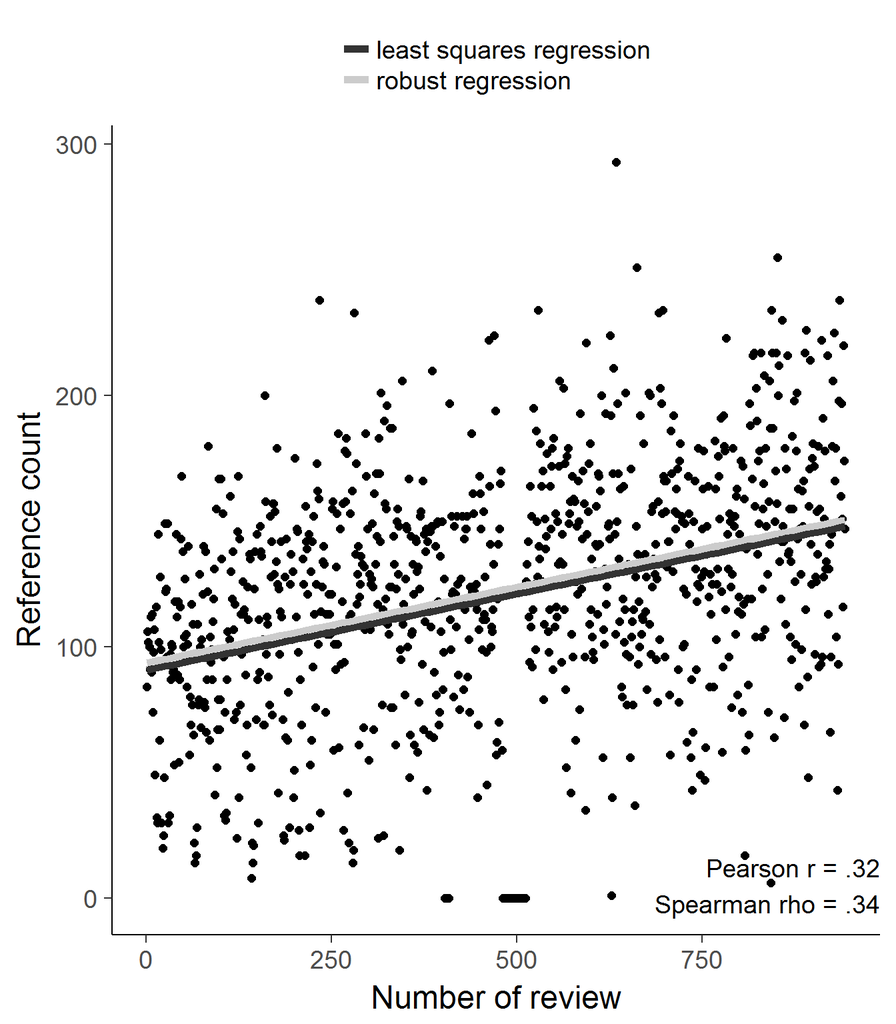

Reviews in NRN include more and more references.

## Concentrate on the most recent literature

```r
dat_hist = data.frame("x" = NRNdat_refyears_adj[
  NRNdat_refyears_adj < 50 &
    NRNdat_refyears_adj > -1])#x-axis: age of referred to scholarly articles (within sensible range)

fig2 = ggplot(dat_hist, aes(x=x)) +
  geom_histogram(color = "black", fill = "gray50") +#add histogram
  labs(x = "Age of reference", y = "Count")+ #add axis titles
  scale_x_continuous(limits = c(0, 50)) +#restrict x-axis range
  ggtitle(" ")#add title
```

Nature Reviews Neuroscience is not the outlet for your history of neuroscience review. Only 22% of cited articles are more than 10 years old. A full 17% of cited articles were published a mere two years prior to the review being published, i.e. something like one year before the first draft of the review reached Nature Reviews Neuroscience (assuming a fast review process of 1 year).

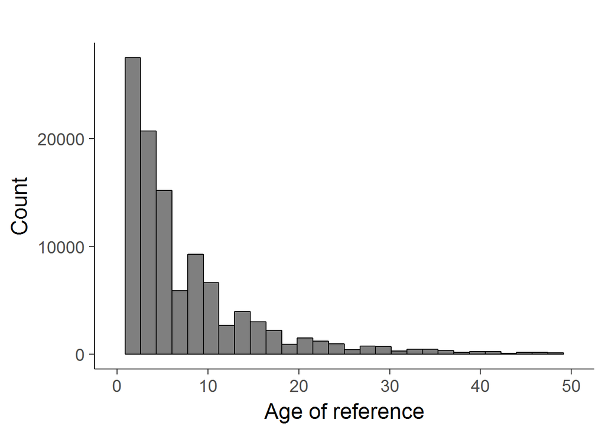

Focus on recent findings. Ignore historical contexts.

## If at all, give a historical background early on in your review.

```r
########################################################
#FIGURE 3: distribution of the age of referred to scholarly articles in different parts of each review

coefficients = numeric()#model fit coefficients
plots = list()

for(p in 1:4){#for every plot, i.e every quarter in a review

  NRN_dat_ref_count = (NRNdat_endyear - NRNdat_startyear) / 4#number of references in this quarter

  NRNdat_startendyear = numeric()

  for(r in 1 : length(NRN_dat_ref_count)){#for each review

    NRNdat_startendyear_r = (NRNdat_startyear[r] + NRN_dat_ref_count[r] * (p-1)):
      (NRNdat_startyear[r] + NRN_dat_ref_count[r] * p)#this review's indexes for this quarter

    NRNdat_startendyear = c(NRNdat_startendyear, NRNdat_startendyear_r)#append to other reviews
  }

  refyears_adj_ext = NRNdat_refyears_adj[NRNdat_startendyear]#subset of reference ages which are in this quarter

  dat_hist = data.frame("x" = refyears_adj_ext[
    refyears_adj_ext < 50 &
      refyears_adj_ext > -1])#x-axis: age of referred to scholarly articles (within sensible range)

  fig3x = ggplot(dat_hist, aes(x = x)) +
    geom_histogram(color = "black", fill = "gray50", binwidth = 1) +#add histogram
    labs(x = "Ref age", y = "Count")+ #add axis titles
    scale_x_continuous(limits = c(0, 50), breaks = c(0,25,50)) +#restrict x-axis range
    scale_y_continuous(limits = c(0, 4500)) +#restrict x-axis range
    ggtitle(sprintf("Q %d", p))#add title

  #add model fit
  age = 1 : 49
  h = hist(refyears_adj_ext[refyears_adj_ext < max(50) & refyears_adj_ext > -1], breaks = 50, plot = F);#histogram function provides bin counts
  m1 = lm(h$counts ~ log(age))#model bin counts as a function of reference logged age (log-model is best fitting model after trying out a few)
  pred = predict(m1, interval="conf", newdata=data.frame(age))
  dat_mod = data.frame(age = age, pred = pred[,1])

  fig3x = fig3x +
    geom_line(data = dat_mod, aes(x = age, y = pred),
              linetype = 3, colour = "gray75", size=2)

  plots[[p]] = fig3x

  #save for next step
  coefficients = c(coefficients, coefficients(summary(m1))[2])
}
```

References are given in order of first presentation in Nature Reviews Neuroscience. Dividing this order in quarters allows us to reveal the age distribution of references in the quarter of the review where they are first mentioned. As can be seen in the figure below, the pressure for recency is less severe in the first quarter of your review. It increases thereafter. So, if you want to take a risk and provide a historical context to your review, do so early on.

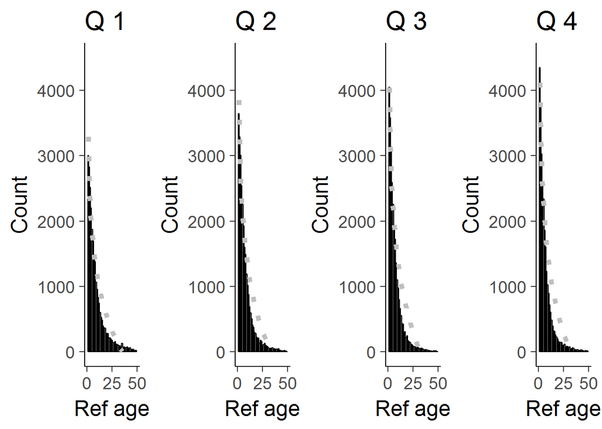

Ignore historical contexts, especially later in your review. Q = quarter in which reference first mentioned

```r
########################################################
#FIGURE 4: development of model fit coefficient ('decline rate') over parts of reviews
dat_vis = data.frame(x = 1:4, y = coefficients)
fig4 = ggplot(dat_vis, aes(x = x, y = y)) +
  geom_bar(stat = "identity") +#add bars
  labs(x = "Quarter within review", y = "Historicalness of references")#axis labels
```

The change in reference age distributions of the different quarters of reviews is not easily visible. Therefore, I fit a logarithmic model to the distributions (notice dotted line in Figure above) and used its parameter estimates as a representation of how ‘historical’ references are. Of course, the average reference is not historical, hence the negative values. But notice how the parameter estimates become more negative in progressive quarters of the reviews: history belongs at the beginning of a review.

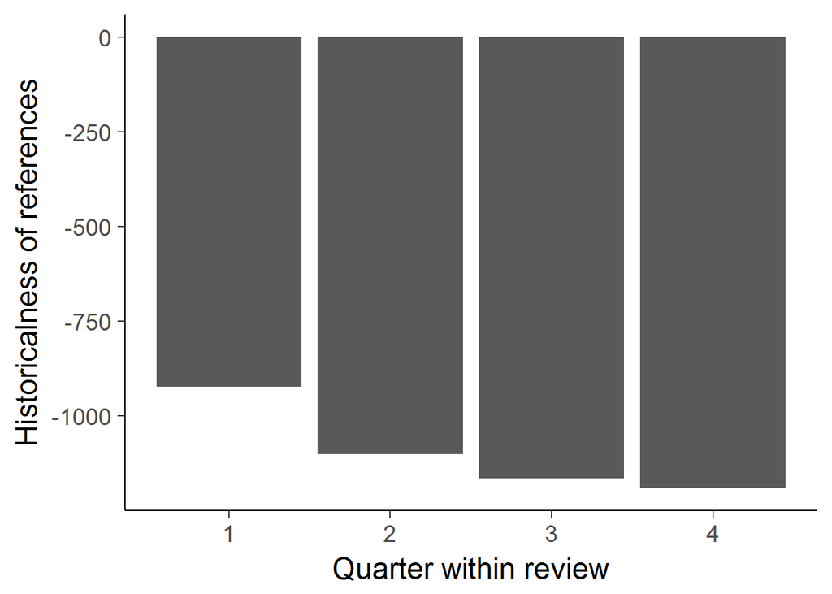

Ignore historical contexts, especially later in your review: the modeling outcome.